# Setting Up MongoDB and Neo4j

Alec J Buchanan

July 20, 2016

# Introduction

This project is designed to showcase how powerful MongoDB and Neo4j can be. MongoDB is a document database, so it is flast and flexable. Neo4j is a graph database and allows people to easily spot relations between the data.

# Setting Up MongoDB and Neo4j

[figure not shown]

Before installing and connecting the databases there is some base software we need to install:  
1. Anaconda3  
2. PIP  
3. neo4j_doc_manager  
4. mongo-connector  
In reality we only need neo4j_doc_manager and mongo-connector, but Anaconda3 and PIP help us get there. To start, the Anaconda installer can be found in my folder of programs or can be easily googled. I had Anaconda installed to the C:/ drive.

The next program we need is PIP. PIP can be found [here](https://bootstrap.pypa.io/get-pip.py). I am not sure what you see on your computer, but on my computer, it is a wall of code. To solve this problem, you need to right click and go to view source. Do not inspect element, because the broweser will attempt to format it and add HTML tags. Save the viewed source page somewhere on your computer. Open the code with notepad++ and change the encoding to utf-8. After thats all done, save it as a .py file and not a .html file. Once you have the .py file, save it to the directory python is in and type “>python get-pip.py”. Congrats, PIP is installed.

After PIP is installed, we can install neo4j_doc_manager by typing “>python –m pip install neo4j-doc-manager –pre”

Finally we have to install mongo-connector. This is the easiest one to install because if you have Anaconda3, you should have mongo-connector. Mongo-connector should be in the scripts folder of Anaconda3.

## MongoDB

[figure not shown]

I got my version of MongoDB from [here](https://www.mongodb.com/download-center?jmp=nav#community). There are a bunch of different version. You will want the one that matches your OS. I got the .msi file from the “Windows Server 2008 R2 64-bit and later, with SSL support” option. Side note: from what I am doing the SSL version is not required.

This documentation is for people who do not have admin rights. This is the only part that will require admin rights. You need to run the .msi file or install it somehow.

After installation has finished, you need to navigate to the bin directory, for me its “> cd C:\program files\MongoDB\server\3.2\bin”

Once in the bin directory, you need to run the daemon “>mongod -replSet rs0”. This command starts the daemon and creates a replica set named rs0. If it works first try, that is great. It will most likely not work on the first try. I got an error saying it could not find the database. The database location is specified within the configuration file, which non privlaged users can not access. One way around this is by adding “-dbpath …” to the startup parameters, but you have to type this in on startup every time. Another solutions is to create the folders “C:\data\db” because this is where Mongo automatically looks for a data base.

Mongodb is finally installed, but it is not setup to work with Neo4j yet. Neo4j_doc_manager requires mongodb to run a primary replica set. When we passed mongo the -replSet rs0 parameter we told it to run a replica set, but it is not yet the primary one. We need to initiate the replica set by typing “>rs.initiate()”. The mongo command line will look like “rs0:OTHER>” when instead of saying “other”" it should say “primary”. To fix this, we need to feed it the command “rs0:OTHER>rs.status()”. MongoDB should not be setup and ready to run.

## Neo4j

Just like every other program that needs to be installed, you need admin rights to get it up and running. After it is installed, It will have a default place to store the database. You can also create a folder and specify a different place. Once it is up and running it will give you a link to access it from your web browser. Neo4j is pretty painless to setup.

## Connecting Mongo to Neo4j

As of now, we have all the software needed to create a working system. To connect Mongo and Neo4j, we need to run mongo-connecctor, but before we do that we need to make sure Mongodb and Neo4j are running. For mongo-connector to work properly we need to give it three parameters: the first is the location of MongoDB; the second is the end point, or the location of Neo4j; and the third is the doc manager. The command I use to execute mongo-connector is “>mongo-connector -m localhost:27017 -t http://localhost:7474/db/data -d neo4j_doc_manager”. Remember, it is important to include the http:// in the endpoint for Neo4j. Hopefully you have not encountered any errors. In the even you have encountered any errors, I have compiled a list of errors and solutions I stumbled upon. Also, there is a chance mongo-connector could fail if you are not running py2neo 2.0.8. The other error you may come accross is a ‘syntax error’ from mongo-connector. This is usually solved by deleting everything in the oplog.timestamp.

# Populating The Database

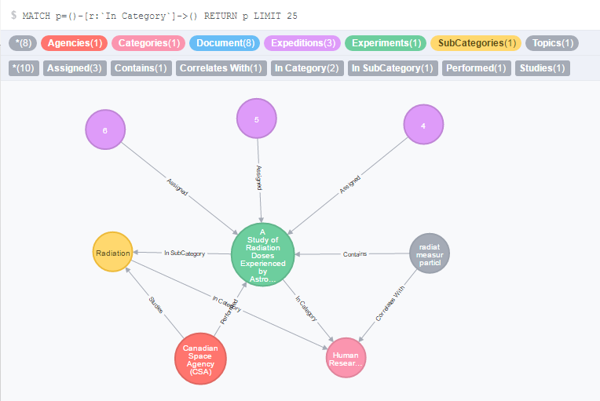

The process of populating the database is a multi level process. The first program we are going to use is Parser3.py. This program goes through and generates almost every node and relationship, except for those having to do with Topics. We will then move to harmonicmean.R where we try to determine the best number of topics to generate. Next we move to modelingData.R where we find the topics and create CSV files. Next we go to Topics.py that creates the topic nodes, contains and relates to relationships.

## Parser3.py

### Setup

I apologize for how sloppy the code is written, but there are a couple steps needed to setup. As of writing this, parentURL on line 31 should be set to NASA’s list of experiments. Starting at line 348, you should make sure that all the directories match how your system environment is setup.

### Functionality

The program first parses through the list of experiments and identifies different categories and sub categories. It will then store them in a list along with which experiments they relate to. The program then visits each experiment page individually breaks it down based on its properties. This is also the phase where Agencies and Expeditions and their relationships are found and stored. Once every experiment has been parsed, the program formats all the relationship information into CQL so Neo4j can understand it. Then all the nodes are converted to JSON and saved to a .json file. After that, they are sent to mongoimport where they are imported into MongoDB and Neo4j. Finally, the relationships are added and the program finishes.

```r
#############################################################
#       Python Web Scraper
#   written in python2 but converted to python 3
#
#   This script will search through NASA's website and parse experiment results and put them into a database
#
#   http://www.nasa.gov/mission_pages/station/research/experiments/experiments_hardware.html
#
#   Needs lxml and requests to work
#
#   ***IMPORTANT***
#       skip to end of file and change file directories to match environment
#
#############################################################

from lxml import html
from lxml import etree #When done delete the unused import line
from lxml.etree import fromstring   #i think i can delete this line
from py2neo import neo4j, Graph, Node, Relationship, rel
import requests         #no need for this anymore
import sys
import os
import json
import time

#reload(sys)
#sys.setdefaultencoding('utf8')

#GLOBAL VARIABLES
#url with list of experiments
parentURL = 'http://www.nasa.gov/mission_pages/station/research/experiments/experiments_hardware.html'
pagesFailed = []

#ignore, variables used later to store nodes and relationships
experimentsDict = {}
categories = []
subCategory = []
agencies = []
relationships = []
expeditions = []

def parseTable(table):
    global subCategory
    global categories
    global experimentsDict
    #these arent really experiements and dont follow the format so they break the program
    ExperimentsToIgnore = ['696',
                            '211',
                            '490',
                            '484',
                            '440',
                            '432',
                            '476',
                            '14',
                            '448',
                            '189',
                            '657',
                            '441',
                            '17',
                            '97',
                            '419',
                            '195',
                            '551',
                            '27',
                            '131',
                            '770',
                            '292',
                            '172',
                            '412',
                            '934',
                            #'1062',#REMOVE THIS
                            #'1973',#REMOVE THIS
                            '192']
    #This part of the function is for determining the section value
    tr = table[0]
    td = tr[0]
    temp =  [x for x in td.itertext()]  #this gets the text node
    section = temp[0]
    print ('*************************** Parsing New Section ******************************')
    print ('*Parsing section:\t' + section)

    categories.append({"title":section,"subs":[]})


    #Done determining the section
    #iterate throught all the sub sections
    #we skip the first element in the list because its an empty <td> used for formatting
    for subSection in table.getchildren()[1:]:
        #Finds subsection title
        #subSection = <tr>
        #temp = tr > td > span > text[]
        temp = [x for x in subSection[1][0].itertext()]
        subSectionTitle = temp[0]
        #some sections have N/A and are blank. Could mean that information will be added later but for right now lets just skip them
        if subSectionTitle == 'N/A': continue
        print ('*Parsing sub section:\t' + subSectionTitle)


        subCategory.append({"title":subSectionTitle,"Experiments":[]})
        categories[-1]["subs"].append(len(subCategory)-1)
        queueRelationship({"collection":"SubCategories","_id":len(subCategory)-1},{"collection":"Categories","_id":len(categories)-1},"In Category")

        #link = all the <a> elements in that subsection
        #we skip the first element because it is a span and contains the title
        for link in subSection[1].getchildren()[1:]:
            #Every other tag is a <br/> so lets skip those
            if link.tag != 'a': continue
            ExpID = getIndex(link.values()[1])
            if ExpID in ExperimentsToIgnore: continue
            subCategory[-1]["Experiments"].append(ExpID)
            experimentsDict[ExpID] = parseExperiment(link.values()[1])
            #Adds experiment to list of experiments and stores relationships between categories and subcategories
            queueRelationship({"collection":"Experiments","_id":ExpID},{"collection":"Categories","_id":len(categories)-1},"In Category")
            queueRelationship({"collection":"Experiments","_id":ExpID},{"collection":"SubCategories","_id":len(subCategory)-1},"In SubCategory")

#Returns experiment id from url ex. experiments/431.html returns 431
def getIndex(link):
    ExpID = link[-9:-5]
    if ExpID[0] == '/': ExpID = ExpID[1:]
    if ExpID[:2] == 's/': ExpID = ExpID[2:]
    if ExpID[:3] == 'ts/': ExpID = ExpID[3:]
    return ExpID
#takes link of experiment, loads it, parses it and creates relationships
def parseExperiment(link):
    ###########IMPORTANT VARIABLES
    global pagesFailed
    global agencies
    global categories
    global expeditions
    location = 'http://www.nasa.gov' + link
    #manually copied and pasted the categories and sub categories
    mainCategories = ['ISS Science for Everyone',
                    'Experiment Details',
                    'Experiment Description',
                    'Applications',
                    'Operations',
                    'Decadal Survey Recommendations',
                    'Results/More Information',   #Exceptions from here down
                    'Results Publications',
                    'Ground Based Results Publications',
                    'ISS Patents',
                    'Related Publications',
                    'Related Websites',
                    'Imagery']
    subCategories = ['Principal Investigator(s)',
                    'Co-Investigator(s)/Collaborator(s)',
                    'Developer(s)',
                    'Sponsoring Space Agency',
                    'Sponsoring Organization',
                    'Research Benefits',
                    'ISS Expedition Duration',
                    'Expeditions Assigned',
                    'Previous ISS Missions',
                    'Science Objectives for Everyone',
                    'Science Results for Everyone',
                    'Previous Missions',
                    'Research Overview',
                    'Description',
                    'Space Applications',
                    'Earth Applications',
                    'Operational Requirements and Protocols',
                    'Operational Requirements',
                    'Operational Protocols']
    ###########LOAD WEBPAGE
    print ('>Loading link:\t' + location)
    document = html.parse(location)
    if document: print ('>Webpage Loaded')
    else:
        #Assumes page failed to load
        print ('>Webpage Failed to locad: ' + location)
        pagesFailed.append(location)
        return
    document = document.getroot()
```

```r
    ###########WEBPAGE LOADED
    #TEMP VARIABLES
    #root = div.pane-content > div
    root = document.find_class('pane-content')[2][2]
    experiment = {} #using a dictionary to store all the information
    text = [x for x in root.itertext()] #all text nodes
    counter = 0
    category = ''
    subCatHeader = ''
    temp = {}

    #IDENTIFY TITLE and DATE
    header = document.find_class('panel-pane pane-custom pane-2')[0][0]
    headerText = [x for x in header.itertext()]
    #Sets title and date appropriatly then checks if date even exists
    title = headerText[0].replace('"',"").replace('\"',"")
    date = headerText[0][-8:]

    if len(date.split('.')) == 3:
        title = headerText[0][:-11].replace('"',"").replace('\"',"")
    else:
        date = 'unknown'
    #####################
    experiment['title'] = title
    experiment['date'] = date
    experiment["_id"] = getIndex(link)
    ###########LOOP THROUGH ALL THE TEXT NODES
    # the first ~16 nodes are just useless links and formatting nodes
    for x in text[16:]:
        #Filter out the useless nodes that are from the poor web design
        node = x
        node = node.replace("\n","")
        node = node.replace("\r","")
        node = node.replace("\t","")
        node = node.replace('"',"")     #these two lines resolve the problem when creating JSON files
        node = node.replace("\"","")
        node = node.strip()
        test = node.replace(" ","")
        if test == "": continue
        #useless nodes
        if node == '' or node == '^ back to top' or "The following content was provided by" in node or 'OpNom:' in node:
            continue
        ###############################################################

        #defines categories
        if node in mainCategories:
            category = node
            if node == 'Imagery': break
            experiment[category] = ''
            temp = {}
            subCatHeader = ''

        elif node in subCategories:
            #For some unknown reason this if statement is skipped the first time its is true
            subCatHeader = node
            temp[subCatHeader] = ''
        else:
            if subCatHeader == '' and category == mainCategories[0]:
                #This statement is used to fix the problem above about the if statement being skipped
                subCatHeader = node
                temp[subCatHeader] = ''
                continue
            if subCatHeader == '':
                #Defines the sub category
                if experiment[category] == '': experiment[category] = node
                else: experiment[category] = experiment[category] + '\n' + node
            else:
                #Defines the info associated with the sub category or category
                if temp[subCatHeader] == '': temp[subCatHeader] = node
                else: temp[subCatHeader] = temp[subCatHeader] + '\n' + node
                experiment[category] = temp
                #Creates a list of agencies and defines relationships
                if subCatHeader == 'Sponsoring Space Agency' and category == 'Experiment Details':
                    if node not in agencies:
                        agencies.append(node)
                    agencyIndex = agencies.index(node)
                    queueRelationship({"collection":"Agencies","_id":agencyIndex},{"collection":"Experiments","_id":experiment["_id"]},"Performed")
                    #queueRelationship({"collection":"Agencies","_id":agencyIndex},{"collection":"Categories","_id":len(categories)-1},"Studies") Agencies -> studies -> categories
                    queueRelationship({"collection":"Agencies","_id":agencyIndex},{"collection":"SubCategories","_id":len(subCategory)-1},"Studies")#UNCOMMENT TO CREATE RELATIONSHIP BETWEEN SUBCATEGORIES AND AGENCIES
                if subCatHeader == 'Expeditions Assigned' and category == 'Experiment Details':
                    #print(node)
                    exped = node.split(',')
                    for e in exped:
                        if e not in expeditions: expeditions.append(e)
                        expeditionIndex = expeditions.index(e)
                        queueRelationship({"collection":"Expeditions","_id":expeditionIndex},{"collection":"Experiments","_id":experiment["_id"]},"Assigned")
        continue

    return experiment
#This function is for testing purposes
def prettyPrintExperiment(experiment):
    for cat, info in experiment.items():
        print ('Category:\t' + cat)
        if isinstance(info,str):
            print ('\t\t\t' + info)
        else:
            for sub, text in info.items():
                print ('Sub Cat:\t\t' + sub)
                print (text)

def convertToJSON(data):
    #converts experiments list to json format
    temp = '{'
    for cat, info in data.items():
        if isinstance(info,str):
            info.replace('"',"").replace('\"',"")
            if '<!--' in info: continue
            if info != '': temp = temp + '"' + cat + '":"' + info + '",'
        else:
            for sub, text in info.items():
                text.replace('"',"").replace('\"',"")
                if '<!--' in text: continue
                if text != '': temp = temp + '"' + cat + ' - ' + sub + '":"' + text + '",'

    temp = temp[:-1] + '}'
    temp = temp.replace("\o","").replace("\ ","").replace("â€","")

    return temp
#Formats to JSON format
def formatCat(data):
    temp = ''
    for key,value in enumerate(data):
        temp = temp + '{"_id":"' + str(key) + '","title":"' + value['title'] + '"}'
    return temp
#Formats to JSON format
def formatAgency(data):
    temp = ''
    for key,value in enumerate(data):
        temp = temp + '{"_id":"' + str(key) + '","title":"' + value + '"}'
    return temp
#Formats to JSON format
def formatExpeditions():
    global expeditions
    temp = ''
    for key,val in enumerate(expeditions):
        temp = temp + '{"_id":"' + str(key) + '","title":"' + val.replace('\u25cf','') + '"}'
    return temp.replace('\u25cf','')
#Adds relationships to a list
def queueRelationship(start,end,name):
    global relationships
    temp = {"start":start,"end":end,"name":name}
    if name == 'Studies' and temp in relationships: return
    if temp not in relationships: relationships.append(temp)
    #relationships.append(temp)
#takes list of relationships and adds them to the database.
def createRelationships():
    global relationships
    graph = Graph('http://localhost:7474/db/data')
    for r in relationships:
        NodeA = graph.find_one(r["start"]["collection"],property_key = "_id", property_value = str(r["start"]["_id"]))
        NodeB = graph.find_one(r["end"]["collection"],property_key = "_id", property_value = str(r["end"]["_id"]))
        graph.create(rel(NodeA,r["name"],NodeB))
```

```r
##############################################
#
#       This is where the functions stop and where the program begins to execute
#
##############################################


#Gets webpage and checks if loaded properly
document = html.parse(parentURL)
if document: print ('Webpage Loaded')
else:
    #Assuming HTTP status != 200
    print ('Failed to load page')
    sys.exit

#document represents <html> element
document = document.getroot()
#<div class="pane-content"> --> <div>
#root represents the <div> that holds all the table which hold experiment links aka the parent node
root = document.find_class('pane-content')[2][3]

counter = 0
for child in root.getchildren():
    if child.tag == 'table':
        #if counter == 2:
        parseTable(child)
        #counter = counter + 1
#prettyPrintExperiment(exp)

print("****************************************")
print("* Formatting and Importing Documents to MongoDB and Neo4j")
f = open('C:\\Users\\ajbuchan\\Desktop\\Project\\experiment.json','wb')
jobj = ''

#######################################
#
#   ***IMPORTANT***
#
#   change file directories to correctly match environment
#
#
#######################################

for x in experimentsDict.items():
    jobj = jobj + convertToJSON(x[1])
f.write(jobj.replace("\r","").replace("\n","").replace("\t","").encode())
f.close()
os.system("\"C:\\program files\\mongodb\\server\\3.2\\bin\\mongoimport.exe\" --db ISSExperiments --collection Experiments --file C:\\users\\ajbuchan\\desktop\\Project\\experiment.json")


subs = formatCat(subCategory)
f = open('C:\\Users\\ajbuchan\\Desktop\\Project\\subCats.json','w+')
f.write(subs)
f.close()
os.system("\"C:\\program files\\mongodb\\server\\3.2\\bin\\mongoimport.exe\" --db ISSExperiments --collection SubCategories --file C:\\users\\ajbuchan\\desktop\\Project\\subCats.json")


cats = formatCat(categories)
f = open('C:\\Users\\ajbuchan\\Desktop\\Project\\cats.json','w+')
f.write(cats)
f.close()
os.system("\"C:\\program files\\mongodb\\server\\3.2\\bin\\mongoimport.exe\" --db ISSExperiments --collection Categories --file C:\\users\\ajbuchan\\desktop\\Project\\cats.json")

age = formatAgency(agencies)
f = open('C:\\Users\\ajbuchan\\Desktop\\Project\\agencies.json','w+')
f.write(age)
f.close()
os.system("\"C:\\program files\\mongodb\\server\\3.2\\bin\\mongoimport.exe\" --db ISSExperiments --collection Agencies --file C:\\users\\ajbuchan\\desktop\\Project\\agencies.json")

e = formatExpeditions()
f = open('C:\\Users\\ajbuchan\\Desktop\\Project\\expeditions.json','w+')
f.write(e)
f.close()
os.system("\"C:\\program files\\mongodb\\server\\3.2\\bin\\mongoimport.exe\" --db ISSExperiments --collection Expeditions --file C:\\users\\ajbuchan\\desktop\\Project\\expeditions.json")

print("Done updating, waiting for mongo-connector")
time.sleep(400)
print("mongo-connector is either done or encountered a problem")
print("Generating Relationships")
createRelationships()
print("All Done")
```

# Topic Modeling

Topic modeling is important because it gives us a new way to relate experiments. We will be using R to run the harmonic mean function and generate the relationships and nodes. First we need to run the loaddata.R to load all of our data into a .RData file.

```r
library(rmongodb)

#Connect to mongoDB
mongo <- mongo.create()
mongo.is.connected(mongodb)

#Execute query
cursor <- mongo.find(mongo,"ISSExperiments.Experiments",query='{}', fields = '{"Experiment Description - Research Overview":1,"Experiment Description - Description":1}')
#convert query to dataframe
df <- mongo.cursor.to.data.frame(cursor)
#rename columns
names(df) <- c("id","desc","overview")
#save so next script can load the data
save(df,file="data.RData")
```

## Harmonic Mean

The harmonicmean.R script runs topic modeling with a range of topic numbers. It then runs the harmonic mean function and determines the optimal number of topics for that dataset. If you are using this program on a different dataset than it was intended for, read the comments to determine if anything needs to be changed.

```r
###############################################
#
#     Topic Modeling program
#
#   Reference: https://eight2late.wordpress.com/2015/09/29/a-gentle-introduction-to-topic-modeling-using-r/
#
#
#
#
###############################################

library(tm)
library(topicmodels)
library(SnowballC)

#load data from previous scripit
load("data.RData")

#Format Data
docs <- Corpus(VectorSource(paste(df$desc,df$overview,sep=" ")))
docs <-tm_map(docs,content_transformer(tolower))

#Replace useless characters
toSpace <- content_transformer(function(x, pattern) { return (gsub(pattern, " ", x))})
docs <- tm_map(docs, toSpace, "-")
docs <- tm_map(docs, toSpace, "â€™")
docs <- tm_map(docs, toSpace, "â€˜")
docs <- tm_map(docs, toSpace, "â€¢")
docs <- tm_map(docs, toSpace, "â€")
docs <- tm_map(docs, toSpace, "â€œ")

docs <- tm_map(docs, removePunctuation)
docs <- tm_map(docs, removeNumbers)
docs <- tm_map(docs, removeWords, stopwords("english"))
docs <- tm_map(docs, stripWhitespace)
docs <- tm_map(docs,stemDocument)

#More Formatting
docs <- tm_map(docs, content_transformer(gsub),
               pattern = "organiz", replacement = "organ")
docs <- tm_map(docs, content_transformer(gsub),
               pattern = "organis", replacement = "organ")
docs <- tm_map(docs, content_transformer(gsub),
               pattern = "andgovern", replacement = "govern")
docs <- tm_map(docs, content_transformer(gsub),
               pattern = "inenterpris", replacement = "enterpris")
docs <- tm_map(docs, content_transformer(gsub),
               pattern = "team-", replacement = "team")
#define and eliminate all custom stopwords
myStopwords <- c("can", "say","one","way","use",
                 "also","howev","tell","will",
                 "much","need","take","tend","even",
                 "like","particular","rather","said",
                 "get","well","make","ask","come","end",
                 "first","two","help","often","may",
                 "might","see","someth","thing","point",
                 "post","look","right","now","think","â€˜ve ",
                 "â€˜re ","anoth","put","set","new","good",
                 "want","sure","kind","larg","yes,","day","etc",
                 "quit","sinc","attemp","lack","seen","awar",
                 "littl","ever","moreov","though","found","abl",
                 "enough","far","earli","away","achiev","draw",
                 "last","never","brief","bit","entir","brief",
                 "great","lot","inform","pend")
docs <- tm_map(docs, removeWords, myStopwords)

dtm <- DocumentTermMatrix(docs)
rownames(dtm) <- df$id
freq <- colSums(as.matrix(dtm))

ord <- order(freq,decreasing=TRUE)

#LDA Gibbs topic modeling information
burnin <- 2000
iter <- 1000
thin <- 500
seed <-list(2003,5,63,100001,765) # important for getting consistant results
nstart <- 5
best <- TRUE
k <- 52    #Number of topics
keep <- 50

#Run the LDA Gibbs algorithm 99 times using 2 -> 100 topics
seqk <- seq(2, 100, 1)

rowTotals <- apply(dtm , 1, sum)
dtm   <- dtm[rowTotals> 0, ]

harmonicMean <- function(logLikelihoods, precision = 2000L) {
  llMed <- median(logLikelihoods)
  as.double(llMed - log(mean(exp(-mpfr(logLikelihoods,
                                       prec = precision) + llMed))))
}


#Ignore these lines two lines
#ldaOut <-LDA(dtm,k, method="Gibbs", control=list(nstart=nstart, seed = seed, best=best, burnin = burnin, iter = iter, thin=thin))
#ldaOut.topics <- as.matrix(topics(ldaOut))

#Run LDA Gibbs algorithm and get harmonic mean
system.time(fitted_many <- lapply(seqk,function(k) LDA(dtm,k=k,method="Gibbs",control=list(burnin=burnin,iter=iter,keep=keep))))
logLiks_many <- lapply(fitted_many, function(L)  L@logLiks[-c(1:(burnin/keep))])
hm_many <- sapply(logLiks_many, function(h) harmonicMean(h))
ldaplot <- ggplot(data.frame(seqk, hm_many), aes(x=seqk, y=hm_many)) + geom_path(lwd=1.5) +
  theme(text = element_text(family= NULL),
        axis.title.y=element_text(vjust=1, size=16),
        axis.title.x=element_text(vjust=-.5, size=16),
        axis.text=element_text(size=16),
        plot.title=element_text(size=20)) +
  xlab('Number of Topics') +
  ylab('Harmonic Mean') +
  annotate("text", x = 25, y = -80000, label = paste("The optimal number of topics is", seqk[which.max(hm_many)])) +
  ggtitle(expression(atop("Latent Dirichlet Allocation Analysis of NEN LLIS", atop(italic("How many distinct topics in the abstracts?"), ""))))
ldaplot
```

[output not shown]

## Generating Topics

ModelingData.R is going to need to be edited before execution. The optimal number of topics we got from the harmonic mean function needs to be used in this script. Towards the middle of the scripts there should be a variable K that needs to be set to the optimal number of topics.

```r
###############################################
#
#     Topic Modeling program
#
#   Reference: https://eight2late.wordpress.com/2015/09/29/a-gentle-introduction-to-topic-modeling-using-r/
#
#
#
#
###############################################

library(tm)
library(topicmodels)
library(SnowballC)

#load data from previous scripit
load("data.RData")

#Format Data
docs <- Corpus(VectorSource(paste(df$desc,df$overview,sep=" ")))
docs <-tm_map(docs,content_transformer(tolower))

#Replace useless characters
toSpace <- content_transformer(function(x, pattern) { return (gsub(pattern, " ", x))})
docs <- tm_map(docs, toSpace, "-")
docs <- tm_map(docs, toSpace, "â€™")
docs <- tm_map(docs, toSpace, "â€˜")
docs <- tm_map(docs, toSpace, "â€¢")
docs <- tm_map(docs, toSpace, "â€")
docs <- tm_map(docs, toSpace, "â€œ")

docs <- tm_map(docs, removePunctuation)
docs <- tm_map(docs, removeNumbers)
docs <- tm_map(docs, removeWords, stopwords("english"))
docs <- tm_map(docs, stripWhitespace)
docs <- tm_map(docs,stemDocument)

#More Formatting
docs <- tm_map(docs, content_transformer(gsub),
               pattern = "organiz", replacement = "organ")
docs <- tm_map(docs, content_transformer(gsub),
               pattern = "organis", replacement = "organ")
docs <- tm_map(docs, content_transformer(gsub),
               pattern = "andgovern", replacement = "govern")
docs <- tm_map(docs, content_transformer(gsub),
               pattern = "inenterpris", replacement = "enterpris")
docs <- tm_map(docs, content_transformer(gsub),
               pattern = "team-", replacement = "team")
#define and eliminate all custom stopwords
myStopwords <- c("can", "say","one","way","use",
                 "also","howev","tell","will",
                 "much","need","take","tend","even",
                 "like","particular","rather","said",
                 "get","well","make","ask","come","end",
                 "first","two","help","often","may",
                 "might","see","someth","thing","point",
                 "post","look","right","now","think","â€˜ve ",
                 "â€˜re ","anoth","put","set","new","good",
                 "want","sure","kind","larg","yes,","day","etc",
                 "quit","sinc","attemp","lack","seen","awar",
                 "littl","ever","moreov","though","found","abl",
                 "enough","far","earli","away","achiev","draw",
                 "last","never","brief","bit","entir","brief",
                 "great","lot","inform","pend")
docs <- tm_map(docs, removeWords, myStopwords)

dtm <- DocumentTermMatrix(docs)
rownames(dtm) <- df$id
freq <- colSums(as.matrix(dtm))

ord <- order(freq,decreasing=TRUE)

#LDA Gibbs topic modeling information
burnin <- 2000
iter <- 1000
thin <- 500
seed <-list(2003,5,63,100001,765) # important for getting consistant results
nstart <- 5
best <- TRUE
k <- 52    #Number of topics
keep <- 50

# Run the topic modeling
ldaOut <-LDA(dtm,k, method="Gibbs", control=list(nstart=nstart, seed = seed, best=best, burnin = burnin, iter = iter, thin=thin))

#Match experiment to topic
ldaOut.topics <- as.matrix(topics(ldaOut))
write.csv(ldaOut.topics,file=paste("LDAGibbs",k,"DocsToTopics.csv"))

#Match terms to topic
ldaOut.terms <- as.matrix(terms(ldaOut,6))
write.csv(ldaOut.terms,file=paste("LDAGibbs",k,"TopicsToTerms.csv"))

#Get strength of relation of each experiemtn and topic
topicProbabilities <- as.data.frame(ldaOut@gamma)
write.csv(topicProbabilities,file=paste("LDAGibbs",k,"TopicProbabilities.csv"))

#find importance of topics
topic1ToTopic2 <- lapply(1:nrow(dtm),function(x)
  sort(topicProbabilities[x,])[k]/sort(topicProbabilities[x,])[k-1])

topic2ToTopic3 <- lapply(1:nrow(dtm),function(x)
  sort(topicProbabilities[x,])[k-1]/sort(topicProbabilities[x,])[k-2])

write.csv(topic1ToTopic2,file=paste("LDAGibbs",k,"Topic1ToTopic2.csv"))
write.csv(topic2ToTopic3,file=paste("LDAGibbs",k,"Topic2ToTopic3.csv"))
```

# Populating The Database Continued

## importing Topics

Before we can start importing the topics we created, we need to edit some files. Go into the topicing directory and edit TopicImporting.py and RelatesTo.py. When editing the file you want to look for anywhere a directory is mentioned and edit it to match your system environment. Once the files have been edited, go back a directory and run the Topics.py script.

### TopicImporting.py

```r
########################################################
#
#       TOPIC IMPORTING
#
#   Input:
#       loads csv file with format:
#
#           Topic 1 | Topic 2 | Topci 3 | Topic 4 | ...
#           --------+---------+---------+---------+------
#           space   | area    | crew    | space   | ...
#           --------+---------+---------+---------+------
#           flight  | ant     | member  | ISS     | ...
#           --------+---------+---------+---------+------
#           ......  | ...     | ......  | ...     | ...
#
#
#   Usage:
#       Specify the number of terms to take from each topic. then run it
#
#       Must have mongoimport set up
#
#       *NOTICE: this program only takes csv files in utf-8
#
#
#   JSON format:
#       JSON =  {"_id":pos in array,"name":"Topic X","value":"space flight long"}
#               {"_id":pos in array,"name":"Topic X","value":"area ant densiti"}
#
#
########################################################
from py2neo import neo4j, Graph, Node, Relationship, rel
import sys
import os
import json
import csv
import time

#Global Variables
TopicPath = "C:/users/ajbuchan/desktop/Project/testEnviroment/data2/LDAGibbs 52 TopicsToTerms utf8.csv"
DocToTopicPath = "C:/users/ajbuchan/desktop/Project/testEnviroment/data2/LDAGibbs 52 DocsToTopics.csv"
numberOfTerms = 3
relationships = []



def queueRelationship(start,end,name):
    global relationships
    temp = {"start":start,"end":end,"name":name}
    relationships.append(temp)
    #relationships.append(temp)
def createRelationships():
    global relationships
    graph = Graph('http://localhost:7474/db/data')
    for r in range(1,len(relationships)):
        print(r)
        print(relationships[r])
        NodeA = graph.find_one(relationships[r]["start"]["collection"],property_key = "_id", property_value = str(relationships[r]["start"]["_id"]))
        NodeB = graph.find_one(relationships[r]["end"]["collection"],property_key = "_id", property_value = str(relationships[r]["end"]["_id"]))
        graph.create(rel(NodeA,relationships[r]["name"],NodeB))


fileDesc = open(TopicPath,encoding="utf8")
file = csv.reader(fileDesc)


#convert reader iterable to navagateable list
dataStruct = []
tempNum = numberOfTerms
for row in file:
    if tempNum == -1: break
    temp = []
    for col in row:
        temp.append(col)
    dataStruct.append(temp)
    tempNum = tempNum - 1

d = {}
jsonString = ''
cols = len(dataStruct[0])
rows = len(dataStruct)
#Iterate through multidemensional array and convert it to a JSON string
for col in range(1,cols):
    #the commented out one creates json object like this: {"_id":1, "Title":"Topic 1", "Value": "liquid flow fluid"}
    #jsonString = jsonString + '{"_id":' + str(col) + ', "title":"' + dataStruct[0][col] + '", "Value": "'
    #Below follows the format of: {"_id":1, "title": "liquid flow fluid"}
    jsonString = jsonString + '{"_id":' + str(col) + ', "title": "'
    for row in range(1,numberOfTerms + 1):
        jsonString = jsonString + dataStruct[row][col] + " "
    jsonString = jsonString[:-1] + '"}'
print(jsonString)

f = open('C:\\Users\\ajbuchan\\Desktop\\Project\\Topics.json','w+')
f.write(jsonString)
f.close()
os.system("\"C:\\program files\\mongodb\\server\\3.2\\bin\\mongoimport.exe\" --db ISSExperiments --collection Topics --file C:\\users\\ajbuchan\\desktop\\Project\\Topics.json")

time.sleep(20)

fileDesc = open(DocToTopicPath,encoding="utf8")
file = csv.reader(fileDesc)

relationships = []
for row in file: queueRelationship({"collection":"Topics","_id":row[1]},{"collection":"Experiments","_id":row[0]},"Contains")
createRelationships()

#print(relationships[38])

#graph = Graph('http://localhost:7474/db/data')
#NodeA = graph.find_one(relationships[1]["start"]["collection"],property_key = "_id", property_value = str(relationships[1]["start"]["_id"]))
#print(NodeA)
#print(relationships[1]["start"]["collection"])
#print(str(relationships[1]["start"]["_id"]))
```

### RelatesTo.py

```r
########################################################
#
#       RELATE TOPICS TO OTHER TOPICS
#
#   Global Variables
#       topicProbability = file path to a utf-8 csv file that contains a table. The rows are individual objects or experiments while the columns represent each topic
#       threshhold = the lowest number considered to represent a relationship
#
#
#
########################################################
from py2neo import neo4j, Graph, Node, Relationship, rel
import sys
import os
import json
import csv
import time

#Global Variables
topicProbability = "C:/users/ajbuchan/desktop/project/testEnviroment/data2/LDAGibbs 52 TopicProbabilities.csv"
threshhold = .15
graph = Graph('http://localhost:7474/db/data')
relations = []

def createRelation(first,second):
    NodeA = graph.find_one("Topics",property_key = "_id", property_value = str(first))
    NodeB = graph.find_one("Topics",property_key = "_id", property_value = str(second))
    relation = rel(NodeA,"Relates to",NodeB)
    #SEARCH FOR RELATIONSHIP AND IF NOT FOUND INSERT IT
    temp = graph.match_one(start_node = NodeA,rel_type = "Relates to",end_node = NodeB)
    if temp == None: graph.create(relation)
    else: print("duplicate found")

print("Opening File")
#Open File
fileDesc = open(topicProbability,encoding="utf8")
file = csv.reader(fileDesc)

print("Parsing file")
#iterate through each entry or row
header = True
for row in file:
    if header:
        header = False
        continue
    temp = []
    #iterate through each value in the row
    for index in range(len(row)):
        value = float(row[index])
        if value >= threshhold and value < 1: temp.append(index)
    if len(temp) < 2: continue
    if temp not in relations: relations.append(temp)
print("Found relationships")

#Creates the relationships
print("Creating relationships")
cypher = graph.cypher
for match in relations:
    if len(match) < 2:continue
    for i in range(len(match) - 1):
        createRelation(match[i],match[i+1])
cypher.execute("MATCH (t:Topics)-[:Contains]->(:Experiments)-[:`In Category`]->(c:Categories) CREATE UNIQUE (t)-[r:`Correlates With`]->(c)")
cypher.execute("MATCH (n) REMOVE n:Document")
```

# Linkurious

[interactive chart not shown]

# Extra

## GeoLocation.r

```r
library(RNeo4j)
library(ggmap)
graph = startGraph("http://jsc-na-vocab:7474/db/data/")
#Function to remove whitespace
trim <- function (x) gsub("^\\s+|\\s+$", "", x)
#Dataframe of principal investigators
investigators <- data.frame(data$'_id',data$'Experiment Details - Principal Investigator(s)',vector(length = 1032),vector(length = 1032))
names(investigators) <- c("id","investigators","long","lat")
#populates the lat and long column of the dataframe with the latitude and long of each principal investigator
for (i in 1:nrow(investigators)){
  #the formatting is horrible, but the most common pattern is that the string ends with ", state/province, country" The problem is this pattern is not followed for every investigator so some queries may fail
  splitString <- strsplit(investigators[i,2],",")
  addressList <- tail(splitString[[1]],n=2)
  address <- paste(trim(addressList[1]),trim(addressList[2]))
  print(address)
  #convert address to cords
  location <- geocode(address)
  investigators[i,3] <- location$lon
  investigators[i,4] <- location$lat
}
#Update database with information
for (i in 1:nrow(investigators)){
  if(!is.na(investigators[i,3]) || !is.na(investigators[i,4])){
    cypher(graph,paste0("MATCH (n:Experiments {_id:'",investigators[i,1],"'}) SET n.long = TOFLOAT(",investigators[i,3],"), n.lat = TOFLOAT(",investigators[i,4],")"))
  }
}
```

This script adds the lat and long properties to experiments in Neo4j. They use the location of the principal investigator along with ggmap to represent locations of the investigators.

## Neo4j2DataFrame.r

```r
library(RNeo4j)

graph = startGraph("http://localhost:7474/db/data/")
query <- "MATCH (e:Experiments)
          MATCH (e:Experiments)-[:`In Category`]->(c:Categories)
          MATCH (e:Experiments)-[:`In SubCategory`]->(s:SubCategories)
          MATCH (e)<-[:Contains]-(t:Topics)
          RETURN e.`Experiment Details - Previous ISS Missions` AS `Experiment Details - Previous ISS Missions`,
          e.`Experiment Details - ISS Expedition Duration` AS `Experiment Details - ISS Expedition Duration`,
          e.`Experiment Description - Research Overview` AS `Experiment Description - Research Overview`,
          e.`Experiment Details - Research Benefits` AS `Experiment Details - Research Benefits`,
          e.`Related Websites` AS `Related Websites`,
          e.`Experiment Details - Developer(s)` AS `Experiment Details - Developer(s)`,
          e.`Operations - Operational Protocols` AS `Operations - Operational Protocols`,
          e.`date` AS `date`,
          e.`ISS Science for Everyone - Science Results for Everyone` AS `ISS Science for Everyone - Science Results for Everyone`,
          e.`Experiment Details - Co-Investigator(s)/Collaborator(s)` AS `Experiment Details - Co-Investigator(s)/Collaborator(s)`,
          e.`Applications - Earth Applications` AS `Applications - Earth Applications`,
          e.`Experiment Details - Sponsoring Space Agency` AS `Experiment Details - Sponsoring Space Agency`,
          e.`Experiment Details - Sponsoring Organization` AS `Experiment Details - Sponsoring Organization`,
          e.`Experiment Details - Principal Investigator(s)` AS `Experiment Details - Principal Investigator(s)`,
          e.`Operations - Operational Requirements` AS `Operations - Operational Requirements`,
          e.`Experiment Details - Expeditions Assigned` AS `Experiment Details - Expeditions Assigned`,
          e.`Experiment Description - Description` AS `Experiment Description - Description`,
          e.`title` AS `title`,
          e.`ISS Science for Everyone - Science Objectives for Everyone` AS `ISS Science for Everyone - Science Objectives for Everyone`,
          e.`_id` AS `_id`,
          e.`Applications - Space Applications` AS `Applications - Space Applications`,
          e.`Results/More Information` AS `Results/More Information`,
          e.`Experiment Details - Previous Missions` AS `Experiment Details - Previous Missions`,
          e.`Related Publications` AS `Related Publications`,
          e.`Operations - Operational Requirements and Protocols` AS `Operations - Operational Requirements and Protocols`,
          e.`Decadal Survey Recommendations` AS `Decadal Survey Recommendations`,
          e.`Results Publications` AS `Results Publications`,
          e.`Ground Based Results Publications` AS `Ground Based Results Publications`,
          e.`ISS Patents` AS `ISS Patents`,
          t.title AS Topic,
          s.title AS SubCategory,
          c.title AS Category"
data <- cypher(graph,query)
save(data,file="data.RData")
```

## MongoDB2DataFrame.r

```r
library(rmongodb)

mongo <- mongo.create()
mongo.is.connected(mongodb)


cursor <- mongo.find(mongo,"ISSExperiments.Expeditions",query='{}', fields = '{"title":1}')
df <- mongo.cursor.to.data.frame(cursor)
names(df) <- c("id","title")

save(df,file="data.RData")
```

## WeightNodes.r

This script will add the weight property to Agency and subcategory nodes. The weight property is calculated based on the number of relationships with that node. The weight property can then be used in Linkurious to size the nodes.

```r
library(RNeo4j)
subs <- unique(data$SubCategories)
graph = startGraph("http://localhost:7474/db/data/")
for (i in subs){
  query <- paste0("MATCH (a:SubCategories {title:'",i,"'})-[r:`In SubCategory`]-() WITH a, count(r) AS weight SET a.weight = weight")
  cypher(graph,query)
}
Agencies <- cypher(graph,"MATCH (a:Agencies) RETURN a.title")
for (i in Agencies){
  query <- paste0("MATCH (a:Agencies {title:'",i,"'})-[r:Performed]-() WITH a, count(r) AS weight SET a.weight = weight")
}
for(i in query){
  cypher(graph,i)
}
```

## Agency Influence in Categories

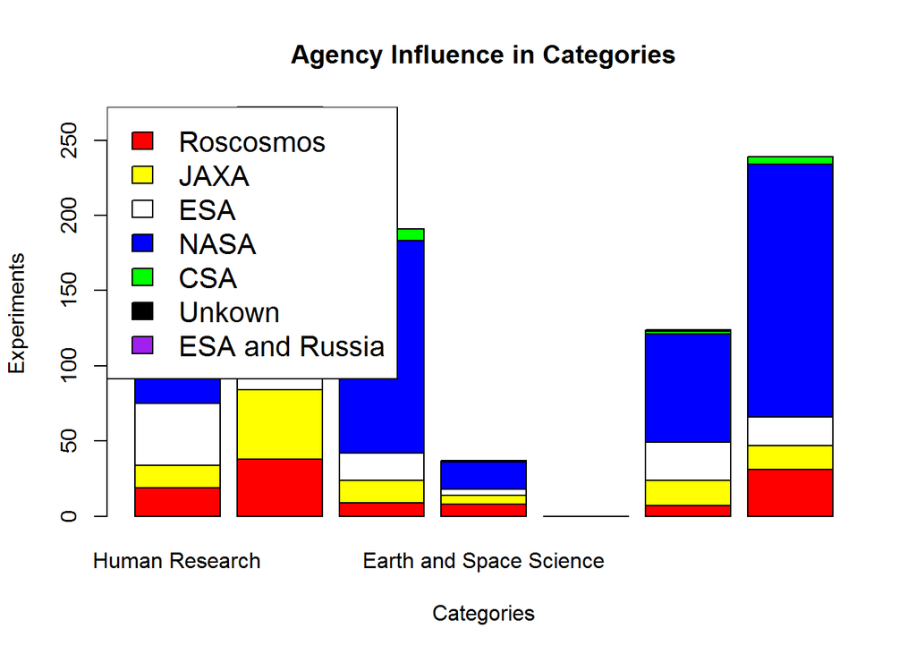

```r
library(RNeo4j)

graph = startGraph("http://localhost:7474/db/data/")

#Load list of agencies and categories
query = "MATCH (a:Agencies) WITH a MATCH (b:Categories) RETURN a.title,b.title"
df <- cypher(graph, query)
names(df) <- c("Agencies","Categories")
#Create list of unique agencies and categories
Agencies = unique(df$Agencies)
Categories = unique(df$Categories)

#Run through every combination of categories and agencies and record the number of relations
vect <- c()
for (i in 1:49){

  query = paste0("MATCH p=(c:Categories)<-[:`In Category`]-(b:Experiments)<-[:Performed]-(a:Agencies) WHERE c.title = '",df$Categories[i],"' AND a.title = '",df$Agencies[i],"' RETURN count(p)")
  temp <- cypher(graph, query)
  vect <- c(vect,temp)
}
#convert vector to matrix
data <- matrix(vect,nrow=7,ncol=7,byrow=TRUE)
#convert matrix to graph
regions <- c("Roscosmos","JAXA","ESA","NASA","CSA","Unkown","ESA and Russia")
colors = c("red","yellow","white","blue","green","black","purple")#c("red","blue","green","white","yellow","purple","black")
barplot(data,main = "Agency Influence in Categories",names.arg = Categories,xlab = "Categories",ylab = "Experiments",las=0,col = colors)
legend("topleft", regions, cex = 1.3, fill = colors)
```